# Everything you always wanted to know about SPICE pointing offsets *

* But were too afraid to ask.

Jupyter notebook → https://github.com/gpelouze/spice_pointing_tutorial

## Overview

- Global offset:
  - $\approx 70$ arcsec constant offset
  - $\approx 20$ arcsec variation over an orbit
- Pointing drift: $\lesssim 5$ arcsec over hours, not measured by the AOCS (Attitude and Orbit Control System)
- Spacecraft jitter: $< 1$ arcsec over minutes, measured by the AOCS

## Global pointing offset

### Offset determination

- Principle: coalign SPICE with EUI FSI (known offset thanks to limb-fitting)
- Method:
  - convert SPICE rasters into Ly γ + C III images by summing over *λ*, correcting for solar rotation at disk centre
  - determine the offset of the FSI 304 Å image closest to the middle of the raster (if there is any) using `euiprep` L1 to L2
  - determine the offset between SPICE and FSI by finding the maximum cross-correlation between the images
- Yields the offset between the SPICE and Solar Orbiter boresights

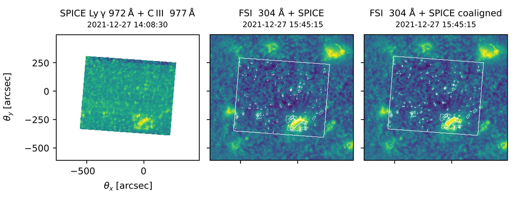

### Offset monitoring

- Apply to observations since 2021-12-01 (STP-180):
  - `SCI_SYNOPTIC_SC_SL04_60.0S_FF` (MISO ID 1963) outside of RSW
  - `SCI_DYN-DEEP_SC_SL04_19.7S_FF` (MISO ID 1975) during RSW
- Offset changes with solar distance

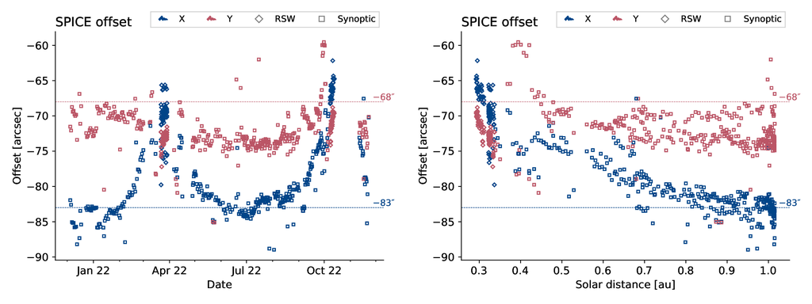

### Temperature dependence

- Offset best correlated to the grating temperature (`T_GRAT` in the FITS headers)
- 1st order fit: $\gtrsim 95$ % of values within 1 FWHM of the SPICE PSF

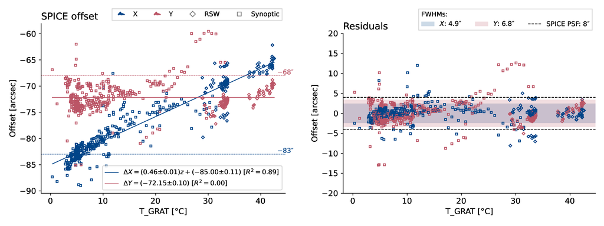

### (Relationship to other parameters)

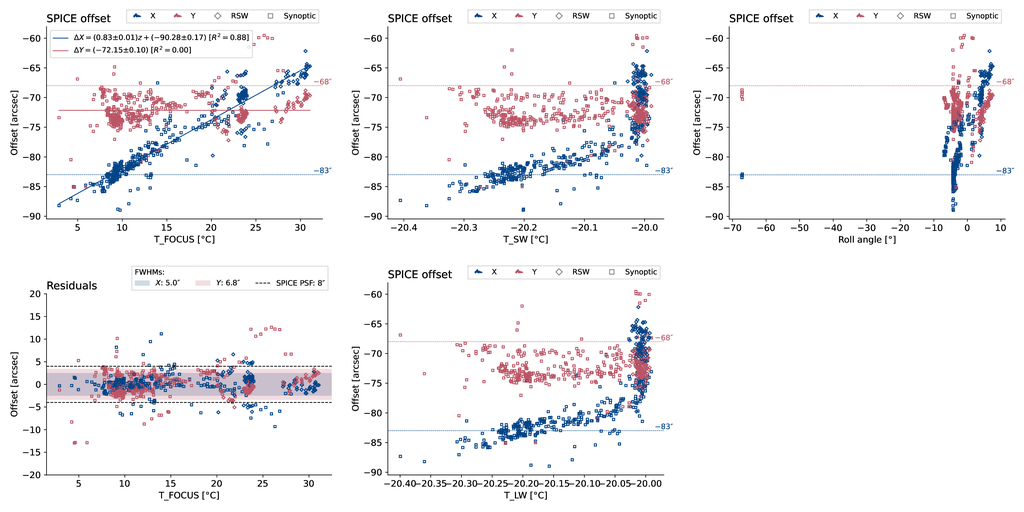

### Recommendations to update the FITS headers

- Current status: 0th order correction from the cruise phase (W. Thompson):
  - $\Delta X = -83$ [arcsec]
  - $\Delta Y = -68$ [arcsec]
- Recommended update: 0th / 1st order correction, accurate within 1 FWHM of the SPICE PSF:
  - $\Delta X = 0.46$ [arcsec / °C] $\times$ `T_GRAT` [°C] $- 85.0$ [arcsec]
  - $\Delta Y = -72.2$ [arcsec]

### Update the headers yourself (for now)

(This step will likely be obsolete in the future, when the FITS files contain the right offset.)

Remove the 0th cruise-phase offset $(−83, −68)$ arcsec, and apply the recommended model:

- $\Delta X = 0.46$ [arcsec / °C] $\times$ `T_GRAT` [°C] $- 85.0$ [arcsec]
- $\Delta Y = -72.2$ [arcsec]

```python
file = 'data/solo_L2_spice-n-ras_20220325T131648_V01_100663893-000.fits'
def rotate(vx, vy, theta):
    return (np.cos(theta) * vx - np.sin(theta) * vy,
            np.sin(theta) * vx + np.cos(theta) * vy)
with fits.open(file) as hdul:
    h = hdul[0].header
    print('CRVAL1:', h['CRVAL1'], 'arcsec')
    print('CRVAL2:', h['CRVAL2'], 'arcsec')
    dx, dy = rotate(h['CRVAL1'], h['CRVAL2'], np.deg2rad(h['CROTA']))
    dx = dx - (- 83) + (0.46 * h['T_GRAT'] - 85.0)
    dy = dy - (- 68) + (- 72.2)
    h['CRVAL1'], h['CRVAL2'] = rotate(dx, dy, np.deg2rad(- h['CROTA']))
    print('new CRVAL1:', h['CRVAL1'], 'arcsec')
    print('new CRVAL2:', h['CRVAL2'], 'arcsec')
```

```
CRVAL1: -79.6110187249 arcsec
CRVAL2: -74.2070821612 arcsec
new CRVAL1: -66.58972877119962 arcsec
new CRVAL2: -79.3861451143989 arcsec
```

### Monitor the global offset yourself

(Content warning)

https://github.com/gpelouze/spice_offset_monitoring

## Spacecraft jitter → you probably don’t need to correct for this one

Small and rapid variations of the spacecraft pointing.

- Most rasters are unaffected (variation $\lesssim 1$ arcsec)
- Spacecraft wobbles after wheel offloading (10 to 30 arcsec variations)

→ Variations are captured by the AOCS (Attitude and Orbit Control System), so they can be corrected if needed.

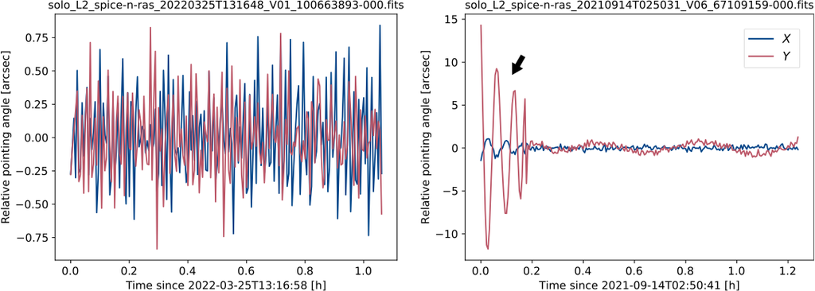

### Correction

- Knowing the pointing offset for each slit position, rasters can be resampled onto a regular grid
- This mixes $X$ and $t$ for large $X$-offsets, so use it carefully

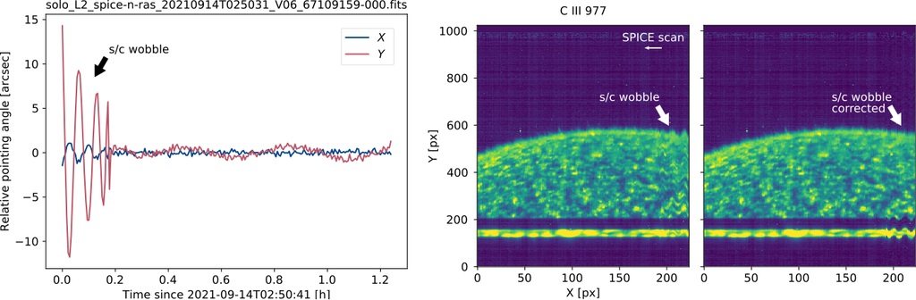

- Case A: per-slit offset is in FITS file (`WCSDVARR` extensions) → resample the raster (spice_jitter_correction)
- Case B: offset is not in the FITS file → compute it with the SPICE kernels and resample the raster (spice_stew)

### Case A: per-slit offset is in FITS file

The per-slit offset is stored in the `WCSDVARR` extensions. `CRDERi` and `CWERi` give the std and maximum variation of the offset within the raster. They should be used to assess whether the correct for the jitter:

```python
file = 'data/solo_L2_spice-n-ras_20210914T025031_V07_67109159-000.fits'
with fits.open(file) as hdul:
    if 'WCSDVARR' in hdul:
        h = hdul[0].header
        print('std ΔX:', h['CRDER1'], 'arcsec')
        print('max ΔX:', h['CWERR1'], 'arcsec')
        print('std ΔY:', h['CRDER2'], 'arcsec')
        print('max ΔY:', h['CWERR2'], 'arcsec')
```

```
std ΔX: 0.175124208406 arcsec
max ΔX: 1.47314388787 arcsec
std ΔY: 0.338068853111 arcsec
max ΔY: 14.1499356645 arcsec
```

#### Plot the variations

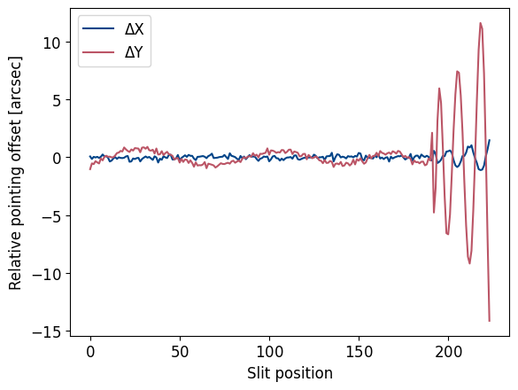

```python
plt.clf()
plt.plot(fits.getdata(file, 'WCSDVARR', 1), label='ΔX')
plt.plot(fits.getdata(file, 'WCSDVARR', 2), label='ΔY')
plt.legend()
plt.xlabel('Slit position')
plt.ylabel('Relative pointing offset [arcsec]')
plt.show()
```

#### Correct the pointing

Use spice_jitter_correction to resample the data onto a regular grid. This creates a “regularized” L2 file (“L2r”).

[output not shown]

[output cut: 31 more lines]

[output not shown]

```
'./data/output_spice_jitter_correction/solo_L2r_spice-n-ras_20210914T025031_V07_67109159-000.fits'
```

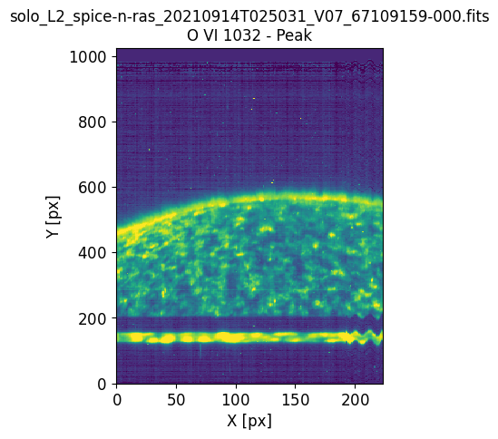

```python
import spice_jitter_correction
spice_jitter_correction.correct_jitter(
    'data/solo_L2_spice-n-ras_20210914T025031_V07_67109159-000.fits',
    './data/output_spice_jitter_correction/',
    plot_results=True,
    )
```